[OHI British Columbia](http://www.ohibc.org/) | [OHI Science](http://ohi-science.org) | [Citation policy](https://github.com/OHI-Science/ohiprep/releases)

# Biodiversity intactness maps

Compiled on Sun Jun 17 11:20:48 2018 by ohara

```r
knitr::opts_chunk$set(fig.width = 6, fig.height = 4, fig.path = 'Figs/',
                      echo = TRUE, message = FALSE, warning = FALSE)

library(raster)
library(data.table)


source('https://raw.githubusercontent.com/oharac/src/master/R/common.R')  ###
  ### includes library(tidyverse); library(stringr); dir_M points to ohi directory

dir_git <- '~/github/spp_risk_dists'

### goal specific folders and info
dir_setup <- file.path(dir_git, 'data_setup')
dir_data  <- file.path(dir_git, 'data')
dir_o_anx <- file.path(dir_O, 'git-annex/spp_risk_dists')

source(file.path(dir_git, 'data_setup/api_fxns.R'))
```

# 1 Summary

Create a set of maps of the distribution of biodiversity intactness - all species assessed and mapped by IUCN. These maps are generated at 0.10° lat/long resolution. These maps will be generated using all available species:

- Mean risk
- Variance of risk
- Number of species for mean/var calculations
- Number of species categorized as “threatened” (i.e. VU, EN, CR)
- Mean trend
- Number of species for trend calculations

A selection of these maps will be generated for taxonomic groups and range sizes in a separate Rmd.

Future iterations may include:

- Range-rarity-weighted mean and variance of risk
- Range rarity-weighted species richness

# 2 Data Sources

IUCN Red List spatial data download IUCN Red List API Gina Ralph (IUCN)

# 3 Methods

## 3.1 Spatial distribution of current extinction risk

### 3.1.1 Aggregate mean risk and variance by cell

In data_setup we have calculated, for each taxonomic group, cell values for mean risk, var risk, n_spp risk, n threatened, mean trend, n_spp trend. Here we bring those data frames all together to calculate these values across all assessed species.

Because of file sizes, the intermediate files will be stored outside of GitHub.

```r
dir_taxa_summaries <- file.path(dir_o_anx, 'taxa_summaries')
sum_files <- list.files(dir_taxa_summaries,
                        pattern = sprintf('%s.csv', api_version),
                        full.names = TRUE)

message('going into the first mclapply...')

cell_values_all <- parallel::mclapply(sum_files, mc.cores = 12,
                                      FUN = function(x) read_csv(x, col_types = 'dddiidi')) %>%
  bind_rows()

### chunk into smaller bits for mclapply usage.  Use mclapply to chunk in the first place!
### then pass result to mclapply to calculate weighted average values
chunksize  <- 10000
cell_ids  <- cell_values_all$cell_id %>% unique()
n_chunks <- ceiling(length(cell_ids) / chunksize)

message('going into the second mclapply...')
# system.time({
  ### standard:  3 sec for 5, 12.5 sec for 20... 32 sec for 50... 479 chunks ~ 6 min.
  ### mclapply: 4 sec for 50, with 32 cores. 52 sec for the whole shebang.
cell_vals_list <- parallel::mclapply(1:n_chunks, mc.cores = 24,
    FUN = function(x) { ### x <- 4783
      btm_i <- (x - 1) * chunksize + 1
      top_i <- min(x * chunksize, length(cell_ids))
      ids <- cell_ids[btm_i:top_i]

      df <- cell_values_all %>%
       filter(cell_id %in% ids)
    }) ### end of mclapply
# })

message('going into the third mclapply...')

# system.time({ ### 514 sec standard; 22.4 sec mclapply with 32 cores.
cell_summary_list <- parallel::mclapply(cell_vals_list, mc.cores = 32,
                                   FUN = function(x) {
  ### x <- cell_vals_list[1:2][[1]]
  y <- x %>%
    group_by(cell_id) %>%
    summarize(mean_risk   = sum(mean_risk * n_spp_risk) / sum(n_spp_risk),
              var_risk    = sum(var_risk * (n_spp_risk - 1), na.rm = TRUE) / sum(n_spp_risk - 1),
                ### https://en.wikipedia.org/wiki/Pooled_variance
              n_spp_risk  = sum(n_spp_risk),
              n_spp_threatened = sum(n_spp_threatened, na.rm = TRUE),
              pct_threatened   = n_spp_threatened / n_spp_risk,
              mean_trend  = sum(mean_trend * n_spp_trend, na.rm = TRUE) / sum(n_spp_trend, na.rm = TRUE),
              n_spp_trend = sum(n_spp_trend, na.rm = TRUE))
  }) ### end of mclapply
# })
message('done!')

cell_summary <- cell_summary_list %>%
  bind_rows()
```

### 3.1.2 And now, the maps

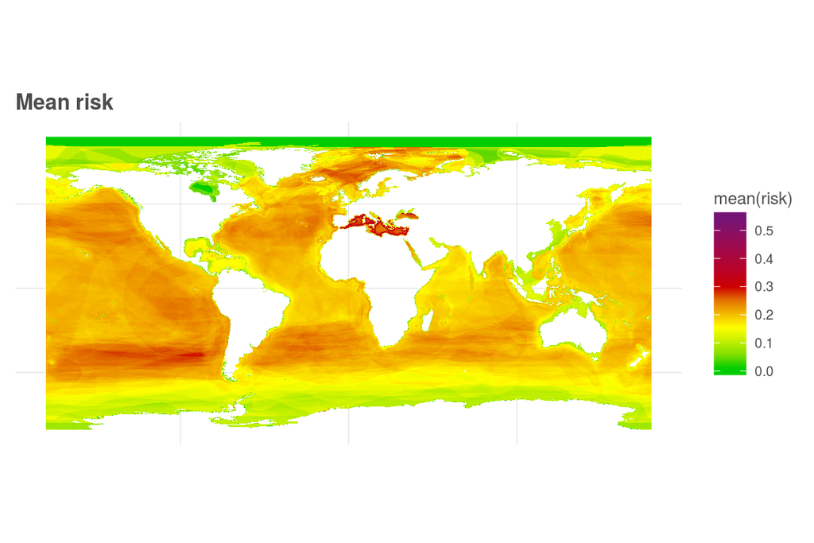

```r
rast_base <- raster(ext = extent(c(-180, 180, -90, 90)), res = 0.1)
values(rast_base) <- 1:length(rast_base)

mean_rast <- subs(rast_base, cell_summary, by = 'cell_id', which = 'mean_risk')
writeRaster(mean_rast, file.path(dir_git, 'output', 'mean_risk_raster_010deg.tif'),
            overwrite = TRUE)

### mean_rast <- raster(file.path(dir_git, 'output', 'mean_risk_raster_010deg.tif'))

mean_df <- mean_rast %>%
  rasterToPoints() %>%
  as.data.frame() %>%
  setNames(c('long', 'lat', 'value'))

message('ggplotting the global map...')

ggplot(mean_df, aes(long, lat, fill = value)) +
  geom_raster() +
  ggtheme_plot() +
  theme(axis.text = element_blank(),
        axis.title = element_blank()) +
  scale_fill_gradientn(colors = c('green3', 'yellow', 'red3', 'purple4'),
                       values = c(0, .25, .5, 1)) +
  coord_fixed() +
  labs(title = 'Mean risk',
       fill  = 'mean(risk)')
```

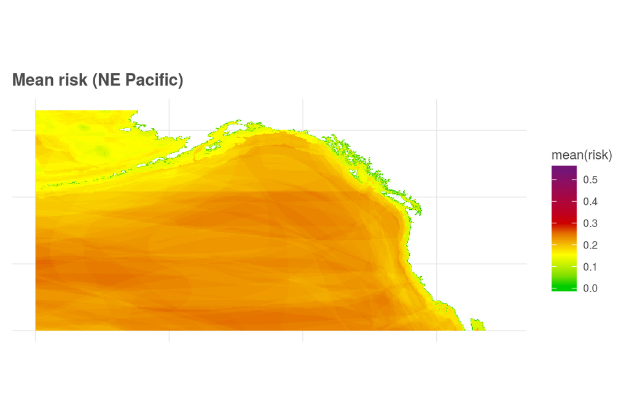

```r
message('now ggplotting the regional maps...')

ggplot(mean_df, aes(long, lat, fill = value)) +
  geom_raster() +
  ggtheme_plot() +
  theme(axis.text = element_blank(),
        axis.title = element_blank()) +
  scale_fill_gradientn(colors = c('green3', 'yellow', 'red3', 'purple4'),
                       values = c(0, .25, .5, 1)) +
  xlim(c(-180, -110)) + ylim(c(30, 63)) +
  coord_fixed() +
  labs(title = 'Mean risk (NE Pacific)',
       fill  = 'mean(risk)')
```

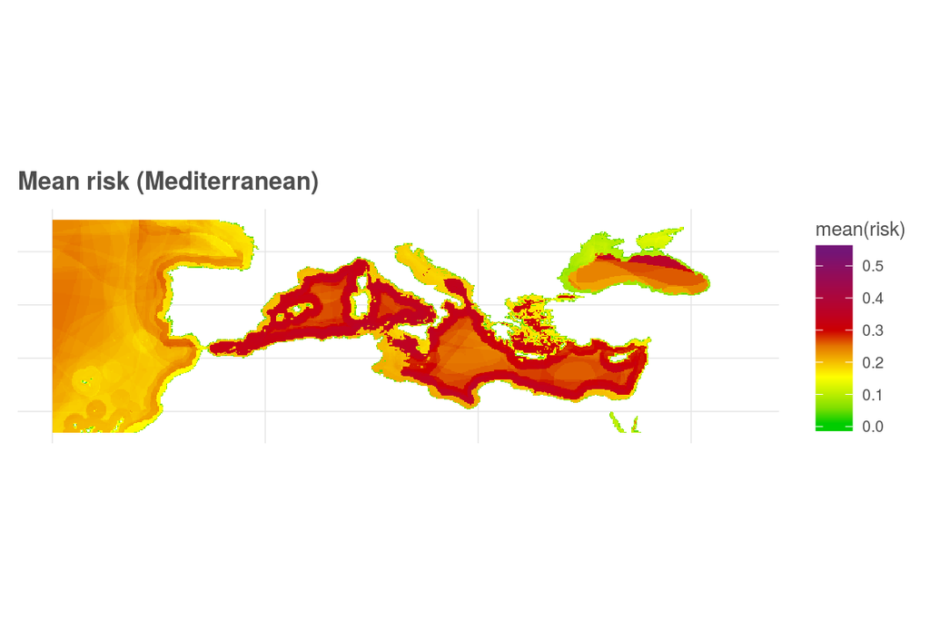

```r
ggplot(mean_df, aes(long, lat, fill = value)) +
  geom_raster() +
  ggtheme_plot() +
  theme(axis.text = element_blank(),
        axis.title = element_blank()) +
  scale_fill_gradientn(colors = c('green3', 'yellow', 'red3', 'purple4'),
                       values = c(0, .25, .5, 1)) +
  xlim(c(-20, 45)) + ylim(c(28, 48)) +
  coord_fixed() +
  labs(title = 'Mean risk (Mediterranean)',
       fill  = 'mean(risk)')
```

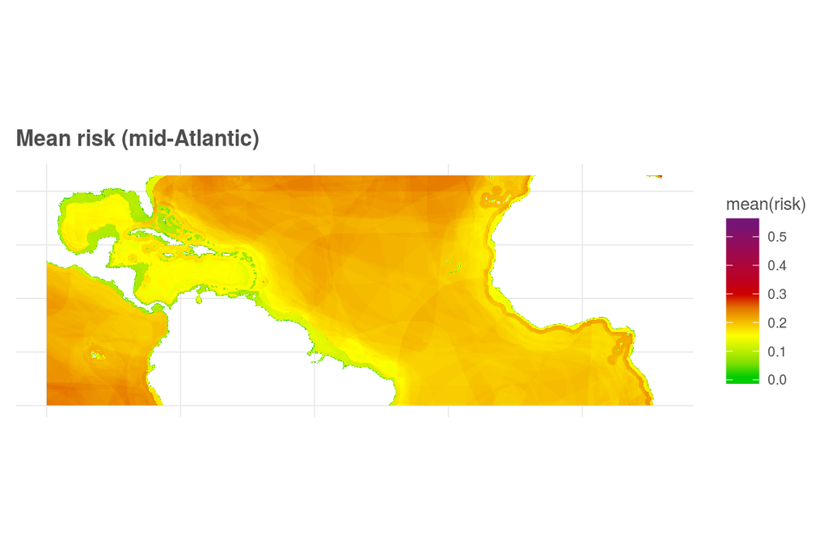

```r
ggplot(mean_df, aes(long, lat, fill = value)) +
  geom_raster() +
  ggtheme_plot() +
  theme(axis.text = element_blank(),
        axis.title = element_blank()) +
  scale_fill_gradientn(colors = c('green3', 'yellow', 'red3', 'purple4'),
                       values = c(0, .25, .5, 1)) +
  xlim(c(-100, 15)) + ylim(c(-10, 33)) +
  coord_fixed() +
  labs(title = 'Mean risk (mid-Atlantic)',
       fill  = 'mean(risk)')
```

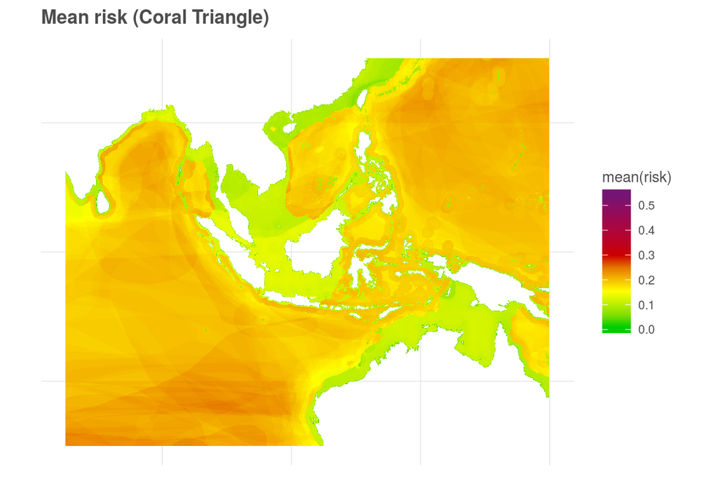

```r
ggplot(mean_df, aes(long, lat, fill = value)) +
  geom_raster() +
  ggtheme_plot() +
  theme(axis.text = element_blank(),
        axis.title = element_blank()) +
  scale_fill_gradientn(colors = c('green3', 'yellow', 'red3', 'purple4'),
                       values = c(0, .25, .5, 1)) +
  xlim(c(75, 150)) + ylim(c(-30, 30)) +
  coord_fixed() +
  labs(title = 'Mean risk (Coral Triangle)',
       fill  = 'mean(risk)')
```

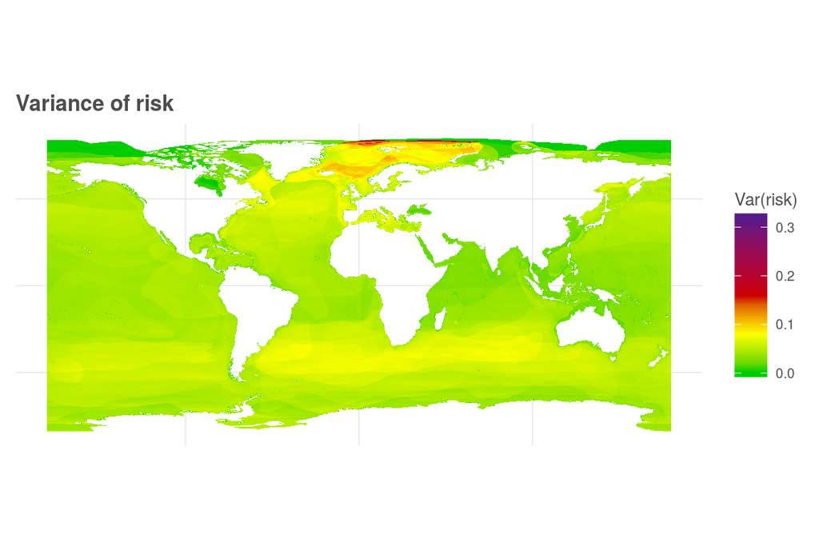

```r
var_rast <- subs(rast_base, cell_summary, by = 'cell_id', which = 'var_risk')
writeRaster(var_rast, file.path(dir_git, 'output', 'var_risk_raster_010deg.tif'),
            overwrite = TRUE)

var_df <- var_rast %>%
  rasterToPoints() %>%
  as.data.frame() %>%
  setNames(c('long', 'lat', 'value'))

ggplot(var_df, aes(long, lat, fill = value)) +
  geom_raster() +
  ggtheme_plot() +
  theme(axis.text = element_blank(),
        axis.title = element_blank()) +
  scale_fill_gradientn(colors = c('green3', 'yellow', 'red3', 'purple4'),
                       values = c(0, .25, .5, 1)) +
  coord_fixed() +
  labs(title = 'Variance of risk',
       fill  = 'Var(risk)')
```

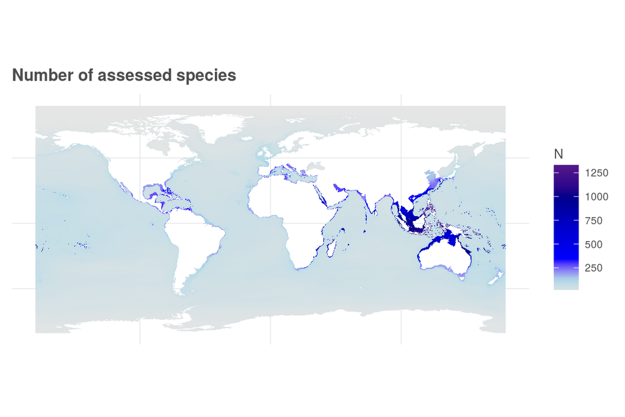

```r
n_spp_rast <- subs(rast_base, cell_summary, by = 'cell_id', which = 'n_spp_risk')
writeRaster(n_spp_rast, file.path(dir_git, 'output', 'n_spp_risk_raster_010deg.tif'),
            overwrite = TRUE)

n_spp_df <- n_spp_rast %>%
  rasterToPoints() %>%
  as.data.frame() %>%
  setNames(c('long', 'lat', 'value'))

ggplot(n_spp_df, aes(long, lat, fill = value)) +
  geom_raster() +
  ggtheme_plot() +
  theme(axis.text = element_blank(),
        axis.title = element_blank()) +
  scale_fill_gradientn(colors = c('grey90', 'lightblue', 'blue1', 'blue3', 'blue4', 'purple4'),
                       values = c(0, .1, .25, .5, .75, 1)) +
  coord_fixed() +
  labs(title = 'Number of assessed species',
       fill = 'N')
```

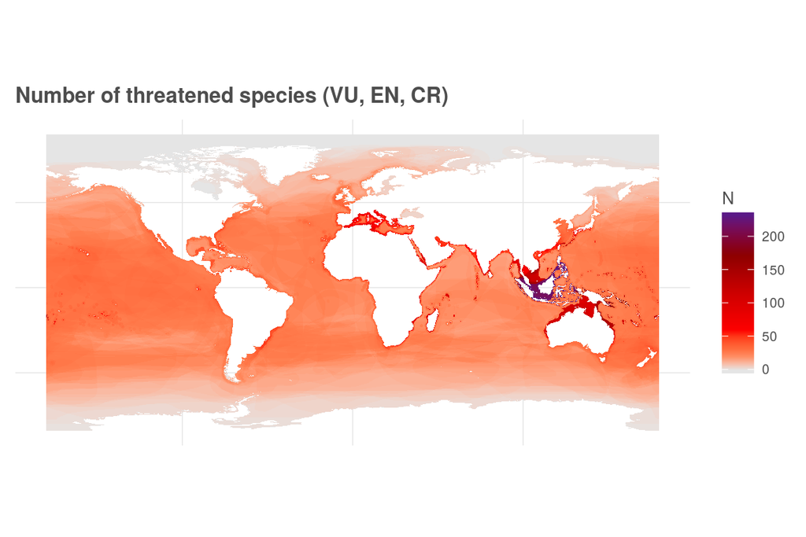

```r
n_threat_rast <- subs(rast_base, cell_summary, by = 'cell_id', which = 'n_spp_threatened')
writeRaster(n_threat_rast, file.path(dir_git, 'output', 'n_threat_raster_010deg.tif'),
            overwrite = TRUE)
### n_threat_rast <- raster(file.path(dir_git, 'output', 'n_threat_raster_010deg.tif'))
n_threat_df <- n_threat_rast %>%
  rasterToPoints() %>%
  as.data.frame() %>%
  setNames(c('long', 'lat', 'value'))


ggplot(n_threat_df, aes(long, lat, fill = value)) +
  geom_raster() +
  ggtheme_plot() +
  theme(axis.text = element_blank(),
        axis.title = element_blank()) +
  scale_fill_gradientn(colors = c('grey90', 'coral', 'red1', 'red3', 'red4', 'purple4'),
                       values = c(0, .1, .25, .5, .75, 1)) +
  coord_fixed() +
  labs(title = 'Number of threatened species (VU, EN, CR)',
       fill  = 'N')
```

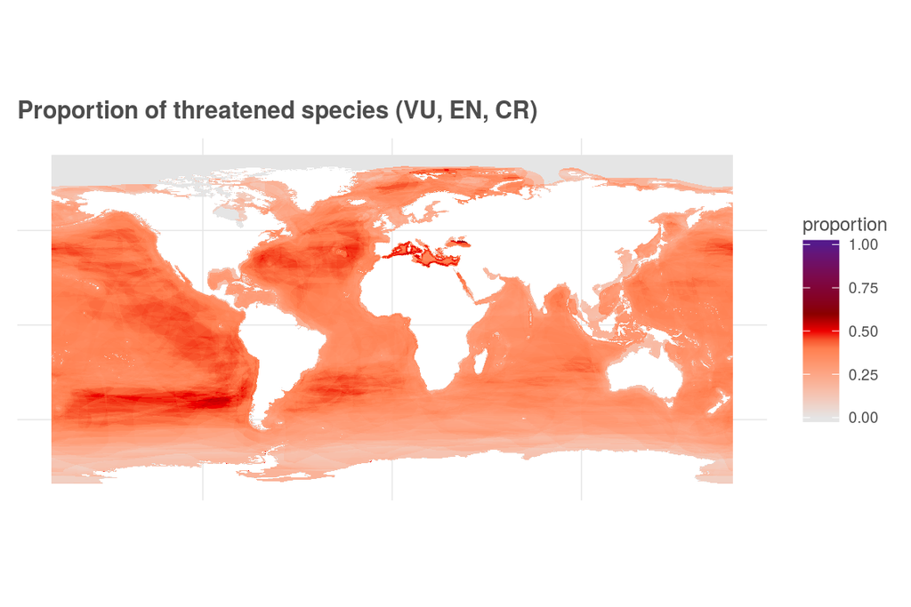

```r
pct_threat_rast <- subs(rast_base, cell_summary, by = 'cell_id', which = 'pct_threatened')
writeRaster(n_threat_rast, file.path(dir_git, 'output', 'pct_threat_raster_010deg.tif'),
            overwrite = TRUE)
### n_threat_rast <- raster(file.path(dir_git, 'output', 'n_threat_raster_010deg.tif'))
pct_threat_df <- pct_threat_rast %>%
  rasterToPoints() %>%
  as.data.frame() %>%
  setNames(c('long', 'lat', 'value'))


ggplot(pct_threat_df, aes(long, lat, fill = value)) +
  geom_raster() +
  ggtheme_plot() +
  theme(axis.text = element_blank(),
        axis.title = element_blank()) +
  scale_fill_gradientn(colors = c('grey90', 'coral', 'red2', 'red4', 'purple4'),
                       values = c(0, .4, .5, .6, 1)) +
  coord_fixed() +
  labs(title = 'Proportion of threatened species (VU, EN, CR)',
       fill  = 'proportion')
```

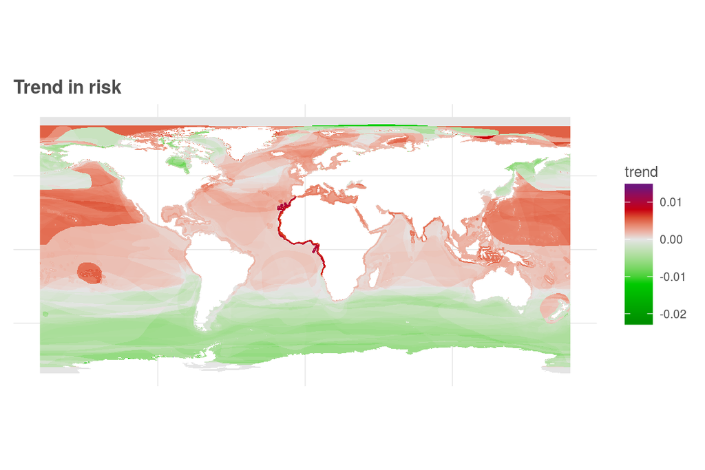

```r
trend_rast <- subs(rast_base, cell_summary, by = 'cell_id', which = 'mean_trend')
writeRaster(trend_rast, file.path(dir_git, 'output', 'trend_raster_010deg.tif'),
            overwrite = TRUE)

trend_df <- trend_rast %>%
  rasterToPoints() %>%
  as.data.frame() %>%
  setNames(c('long', 'lat', 'value'))

trend_range <-range(trend_df$value)
trend_0 <- -trend_range[1] / (trend_range[2] - trend_range[1])

ggplot(trend_df, aes(long, lat, fill = value)) +
  geom_raster() +
  ggtheme_plot() +
  theme(axis.text = element_blank(),
        axis.title = element_blank()) +
  scale_fill_gradientn(colors = c('green4', 'green3', 'grey90', 'red3', 'purple4'),
                       values = c(0, trend_0/2, trend_0, 1 - (1 - trend_0)/2, 1)) +
  coord_fixed() +
  labs(title = 'Trend in risk',
       fill  = 'trend')
```

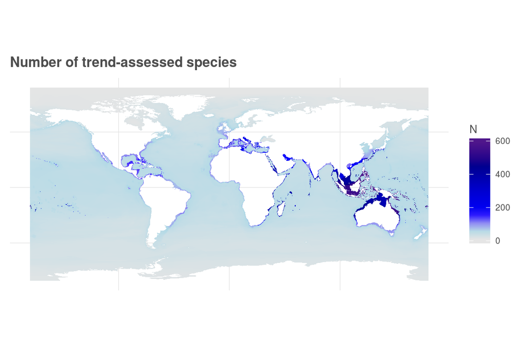

```r
n_trend_rast <- subs(rast_base, cell_summary, by = 'cell_id', which = 'n_spp_trend')
writeRaster(n_trend_rast, file.path(dir_git, 'output', 'n_trend_raster_010deg.tif'),
            overwrite = TRUE)

n_trend_df <- n_trend_rast %>%
  rasterToPoints() %>%
  as.data.frame() %>%
  setNames(c('long', 'lat', 'value'))

ggplot(n_trend_df, aes(long, lat, fill = value)) +
  geom_raster() +
  ggtheme_plot() +
  theme(axis.text = element_blank(),
        axis.title = element_blank()) +
  scale_fill_gradientn(colors = c('grey90', 'lightblue', 'blue1', 'blue3', 'blue4', 'purple4'),
                       values = c(0, .1, .25, .5, .75, 1)) +
  coord_fixed() +
  labs(title = 'Number of trend-assessed species',
       fill  = 'N')
```